# hometask #6

Dmitriy Tsimokha - mglotov.me/da2020<

13.12.20

❅

❅

❆

❄

❅

❆

❄

❅

❆

❄

I’ve chosen **Switzerland** on **9th** round - just because someday I want to live there (*among mountains and forests!*)

```r
library(ggthemr); library(foreign); library(ggplot2); library(stringr);
library(sjPlot); library(stargazer); library(jtools)
ggthemr("lilac", type = "outer")
df <- read.spss("ESS9CH.sav", use.value.labels = T, to.data.frame = T)
df <- na.omit(df[c("plnftr", "trstlgl", "agea", "rshpsts", "bthcld", "gndr")])
df <- na.omit(df)
```

# Variables & model

**My hypothesis**: person’s attitude towards *planning for future or taking each day as it comes* relates on how stable are situation in country with legal system which can be evaluates through person’s *trust in the legal system* attitude - **more trust person have to legal system, more she/he perceive situation in country as stable therefore more planning for future**.

Such relation assumed to have different effect strength with people of different age and on people with/without partners and children: (*I understand that hypotheses for control variables are not used usially, but why not*)  
- **age**: simple case - more years, more planning; complex case - more years (till 50s), more planning & more years (after 50s), less planning  
- **partner**: if there are any partner now, assumed that person plan more  
- **children**: if there are any child(ren), assumed that person plan more

# Variables

- **Dependent**: plnftr: Plan for future or take each day as it comes
- **Predictor**: trstlgl: Trust in the legal system
- *Control*: agea: Age of respondent, calculated
- *Control*: rshpsts: Relationship with husband/wife/partner currently living with
- *Control*: bthcld: Ever given birth to/ fathered a child

## Variables distributions: plnftr

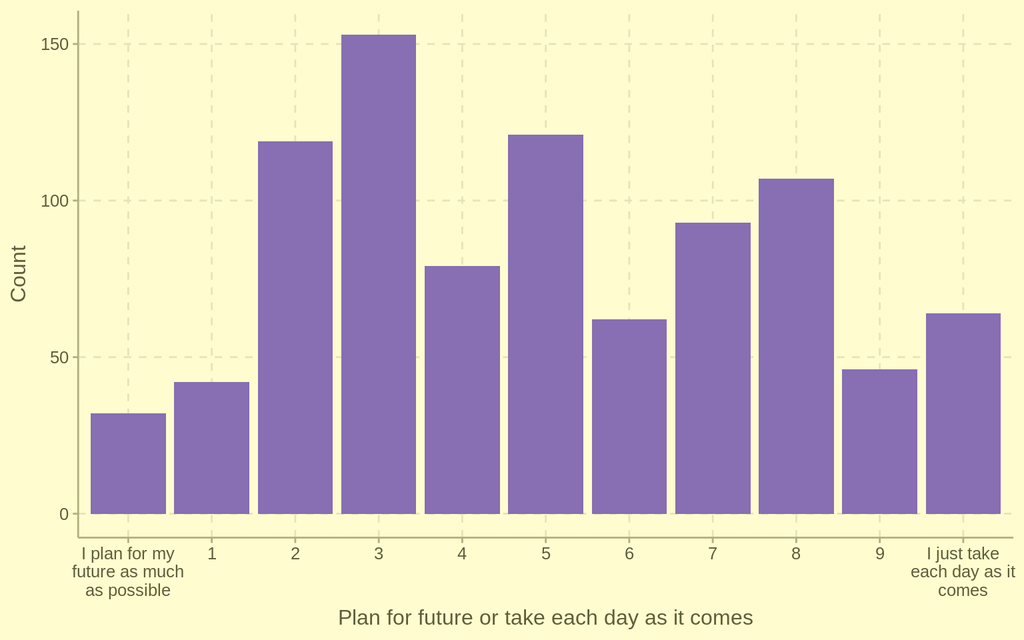

```r
ggplot(df, aes(x = plnftr)) + geom_bar(stat = "count") +
  labs(x = "Plan for future or take each day as it comes", y = "Count") +
  scale_x_discrete(labels = function(x) str_wrap(x, width = 15))
```

So dependent variable distributed not really equally but nevertheless - I will analyse it.

## Variables distributions: trstlgl

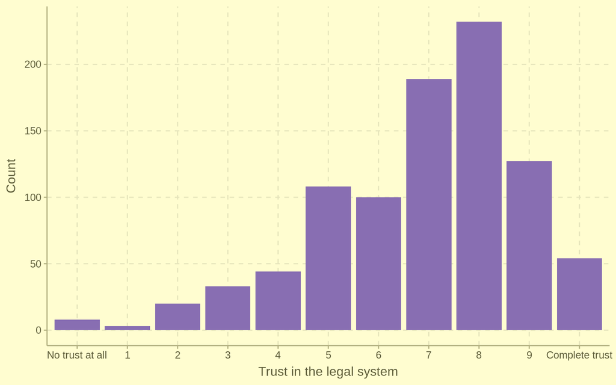

```r
ggplot(df, aes(x = trstlgl)) + geom_bar(stat = "count") +
  labs(x = "Trust in the legal system", y = "Count")
```

## Variables distributions: agea

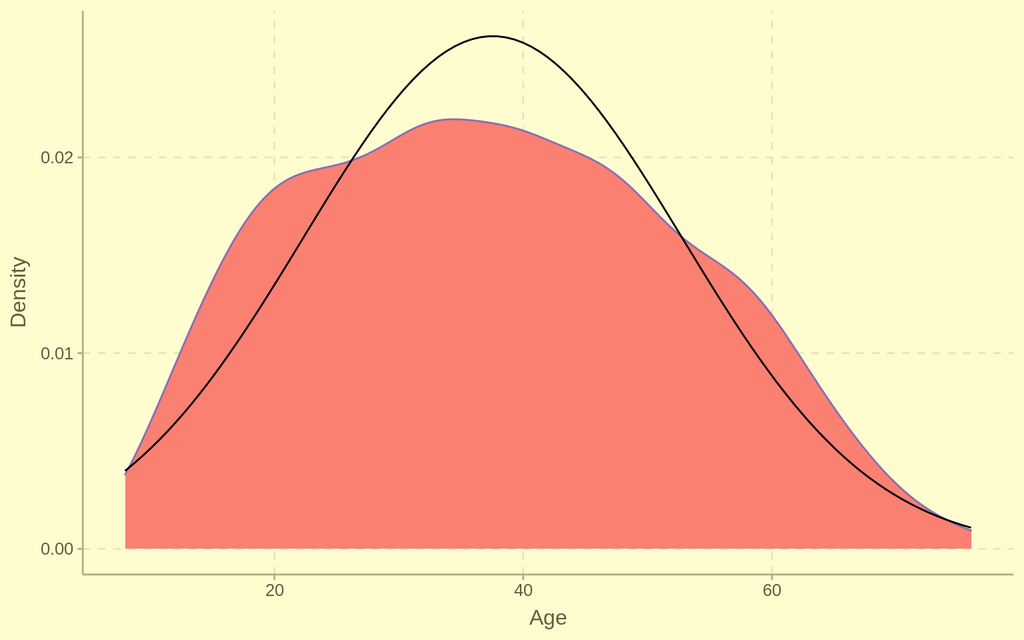

```r
ggplot(df, aes(x = as.numeric(agea))) +
  geom_density(fill = "salmon", stat = 'density') +
  stat_function(fun = dnorm, args = list(mean = mean(as.numeric(df$agea)), sd = sd(as.numeric(df$agea)))) +
  labs(x = "Age", y = "Density")
```

Age distributed normally as always in ESS (*good job*).

## Variables distributions: rshpsts

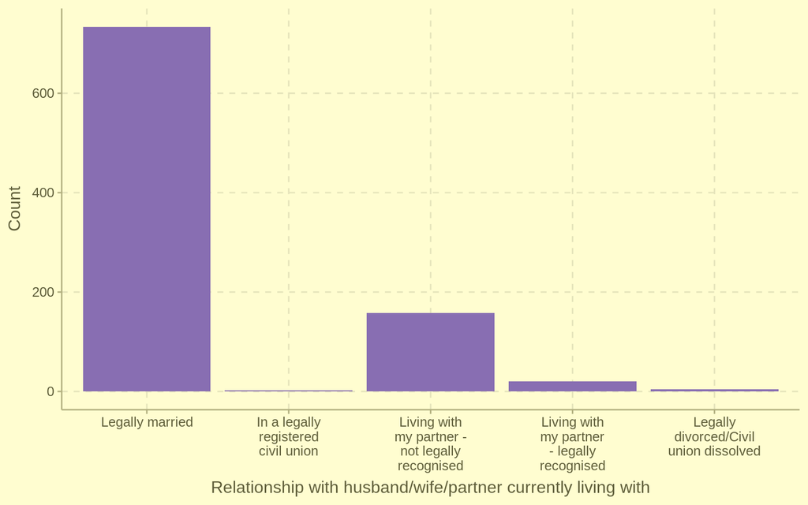

```r
ggplot(df, aes(x = rshpsts)) + geom_bar(stat = "count") +
  scale_x_discrete(labels = function(x) str_wrap(x, width = 15)) +
  labs(x = "Relationship with husband/wife/partner currently living with", y = "Count")
```

And here will be a lot of problems with such distribution. So let’s take **gender as other control** variable instead this one.

## Variables distributions: gndr

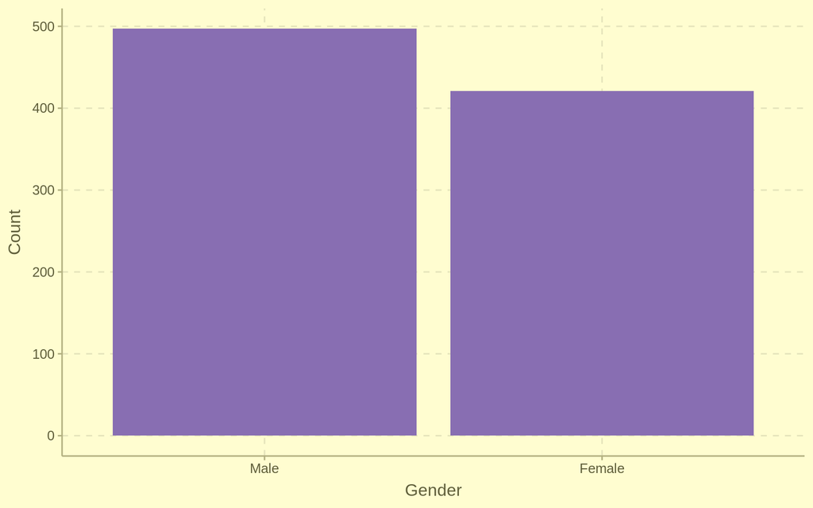

```r
ggplot(df, aes(x = gndr)) + geom_bar(stat = "count") +
  labs(x = "Gender", y = "Count")
```

Very nice (almost uniform) distribution.

## Variables distributions: bthcld

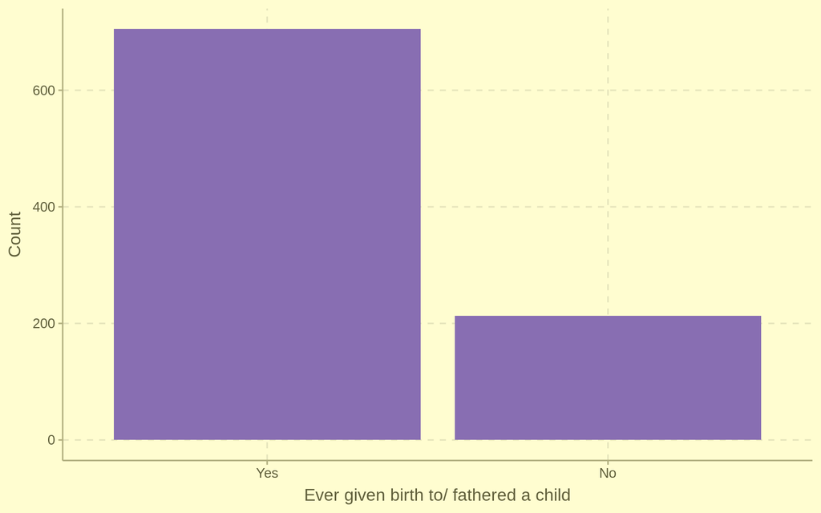

```r
ggplot(df, aes(x = bthcld)) + geom_bar(stat = "count") +
  labs(x = "Ever given birth to/ fathered a child", y = "Count")
```

Not really nice distribution but okay.

# Models

*Remember! I don’t revert the scale of planning for future - zero is more planning attitude!*

## Comparison

```r
model1 <- lm(data = df, as.numeric(plnftr) ~ as.numeric(agea) + gndr + bthcld)
model2 <- lm(data = df, as.numeric(plnftr) ~ as.numeric(trstlgl))
# Main model
model <- lm(data = df, as.numeric(plnftr) ~ as.numeric(trstlgl) + as.numeric(agea) + gndr + bthcld)
tab_model(model, model1, model2, title = "Models comparison", dv.labels = c("predictor & control", "Only control", "Only predictor"))
```

Models comparison

|  | predictor & control |  |  | Only control |  |  | Only predictor |  |  |
| --- | --- | --- | --- | --- | --- | --- | --- | --- | --- |
| Predictors | Estimates | CI | p | Estimates | CI | p | Estimates | CI | p |
| (Intercept) | 4.59 | 3.69 – 5.50 | **<0.001** | 3.49 | 2.96 – 4.03 | **<0.001** | 7.41 | 6.69 – 8.13 | **<0.001** |
| trstlgl | -0.13 | -0.21 – -0.04 | **0.003** |  |  |  | -0.18 | -0.27 – -0.09 | **<0.001** |
| agea | 0.06 | 0.04 – 0.07 | **<0.001** | 0.06 | 0.05 – 0.07 | **<0.001** |  |  |  |
| gndr [Female] | 0.75 | 0.41 – 1.08 | **<0.001** | 0.77 | 0.43 – 1.11 | **<0.001** |  |  |  |
| bthcld [No] | -0.07 | -0.48 – 0.35 | 0.757 | -0.03 | -0.45 – 0.38 | 0.873 |  |  |  |
| Observations | 918 |  |  | 918 |  |  | 918 |  |  |
| R<sup>2</sup> / R<sup>2</sup> adjusted | 0.123 / 0.119 |  |  | 0.115 / 0.112 |  |  | 0.017 / 0.016 |  |  |

As can be seen main difference here is between model with only control variables and model with control variables and key predictor - latter is slightly better than model with only control variables so it can be assumed that usage of key predictor, trust in legal system, is justified.

```r
stargazer(anova(model, model1), type = "html", title="ANoVA", intercept.bottom = FALSE,
          single.row = TRUE, align=TRUE, ci=TRUE, ci.level=0.95, no.space=TRUE)
```

**ANoVA**

| Statistic | N | Mean | St. Dev. | Min | Pctl(25) | Pctl(75) | Max |
| --- | --- | --- | --- | --- | --- | --- | --- |
| Res.Df | 2 | 913.500 | 0.707 | 913 | 913.2 | 913.8 | 914 |
| RSS | 2 | 6,139.137 | 41.447 | 6,109.830 | 6,124.483 | 6,153.791 | 6,168.445 |
| Df | 1 | -1.000 |  | -1.000 | -1.000 | -1.000 | -1.000 |
| Sum of Sq | 1 | -58.615 |  | -58.615 | -58.615 | -58.615 | -58.615 |
| F | 1 | 8.759 |  | 8.759 | 8.759 | 8.759 | 8.759 |
| Pr(> F) | 1 | 0.003 |  | 0.003 | 0.003 | 0.003 | 0.003 |

## Main model

```r
tab_model(model, title = "Main model", dv.labels = c("predictor & control"))
```

Main model

|  | predictor & control |  |  |
| --- | --- | --- | --- |
| Predictors | Estimates | CI | p |
| (Intercept) | 4.59 | 3.69 – 5.50 | **<0.001** |
| trstlgl | -0.13 | -0.21 – -0.04 | **0.003** |
| agea | 0.06 | 0.04 – 0.07 | **<0.001** |
| gndr [Female] | 0.75 | 0.41 – 1.08 | **<0.001** |
| bthcld [No] | -0.07 | -0.48 – 0.35 | 0.757 |
| Observations | 918 |  |  |
| R<sup>2</sup> / R<sup>2</sup> adjusted | 0.123 / 0.119 |  |  |

**Interpretation**:  
- *trust in the legal system* significantly leads to more planning attitude (more trust, more planning)!  
- *age* too have significant effect, but against my hypothesis ()  
- *gender*: have significant effect - females less plan for future than males.  
- *child(ren)*: not significant.

# Assumptions

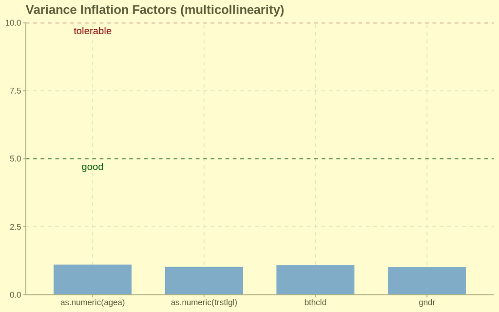

```r
plot_model(model, type = "diag")[[1]]
```

We don’t have any multicollinearity!

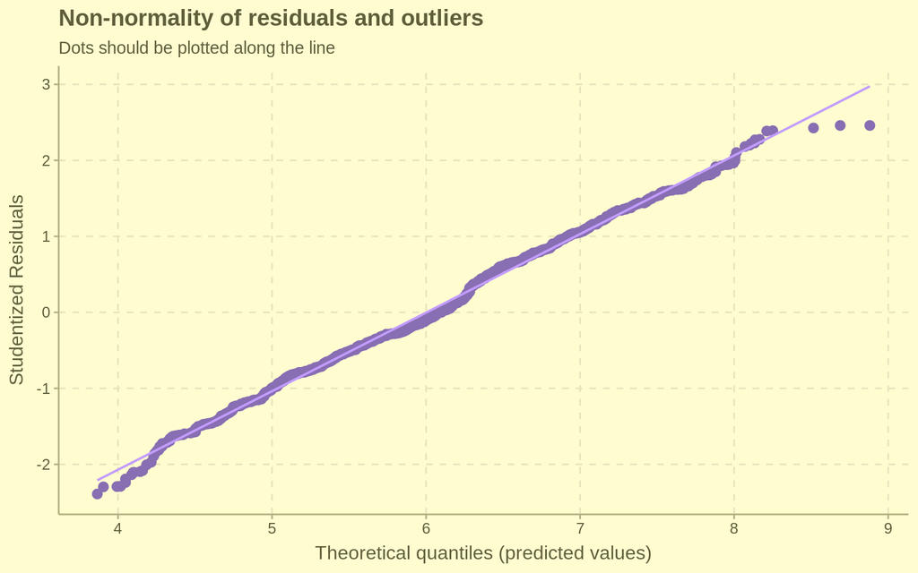

```r
plot_model(model, type = "diag")[[2]]
```

And even residuals distributed normally and there are no major outliers!

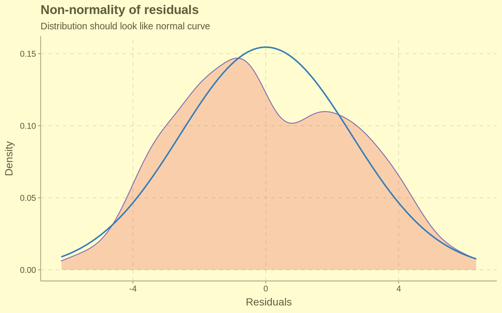

```r
plot_model(model, type = "diag")[[3]]
```

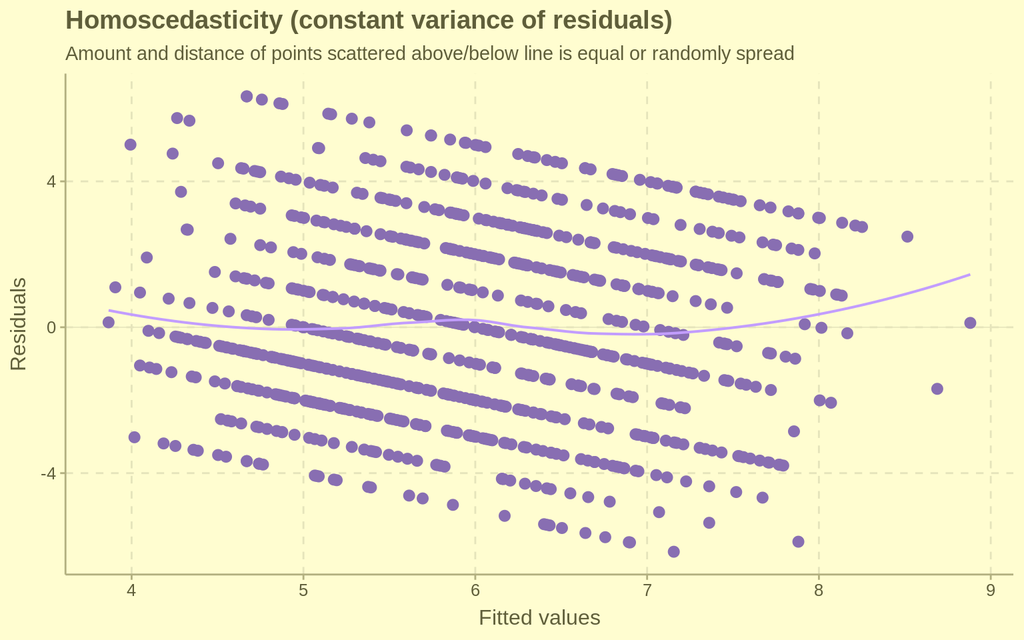

```r
plot_model(model, type = "diag")[[4]]
```

Again - homoscedasticity just not for my models :(

## Viz

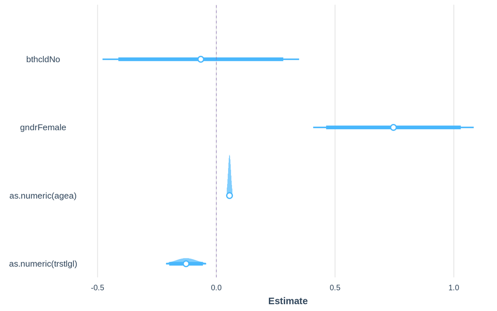

```r
plot_summs(model, plot.distributions = TRUE, inner_ci_level = .9)
```

Plot shows all that already was described in Interpretation.

## Effects

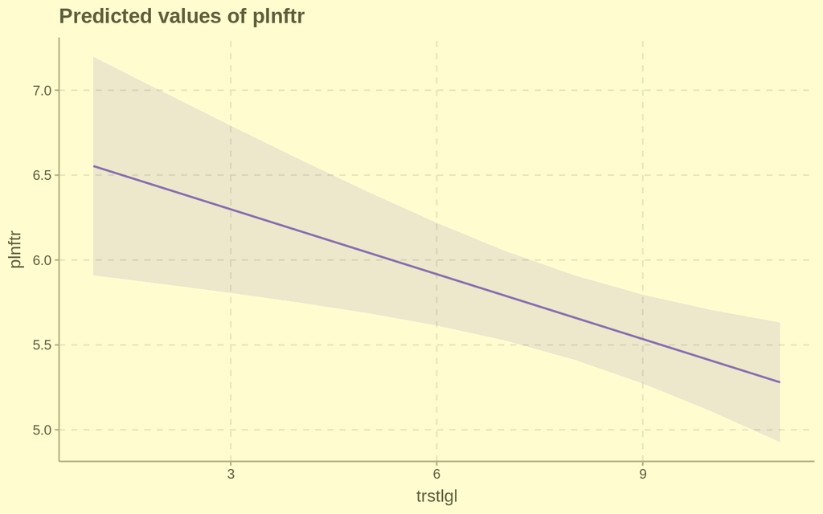

```r
plot_model(model, type = "pred")[[1]]
```

**Trust in the legal system** has significant negative effect and with greater trust people plan more (or with greater trust people less ‘take each day as it comes’)

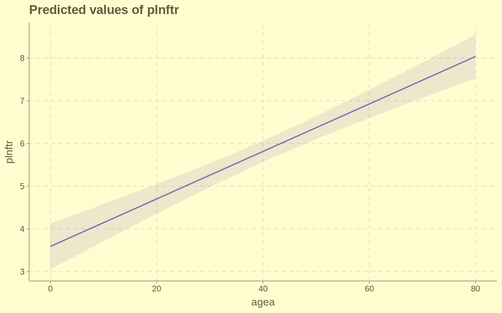

```r
plot_model(model, type = "pred")[[2]]
```

**Age** have significant effect and with more years being on Earth people tend to plan less and more ‘take each day as it comes’ - *some wisdom is hidden here*

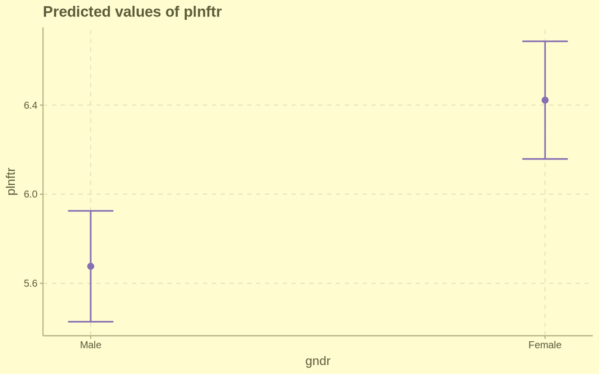

```r
plot_model(model, type = "pred")[[3]]
```

And **gender** - females more ‘take each day as it comes’ than males! (that’s interesting)

# Summary

I came to the conclusion that it is really interesting topic to research - what influences on peoples attitudes to ‘planning for future’ or to ‘take each day as it comes’. I suppose that it is highly connected with perceived stability in the society besides self-efficacy and some minor factors.